# The BioDT Recreational Potential Model for Scotland

Worked example

Authors

Affiliation

Joe Marsh Rossney

UK Centre for Ecology & Hydrology

Maddalena Tigli

Chris Andrews

Jan Dick

Simon Rolph

Published

June 30, 2025

Modified

Abstract

This notebook demonstrates basic usage of the Recreational Potential model. It is assumed that the user is familiar with installing `R` packages, executing lines of `R` code in interactive sessions, and running `R` scripts. Detailed instructions can be found in the `README.md` files in the [GitHub repository](https://github.com/BioDT/uc-ces-recreation).

## Getting started

The Recreational Potential model has been developed on recent (2025) versions of `R` — specifically versions 4.4.2 up to 4.5.0. We cannot guarantee that it will work for versions of `R` outside of this range.

The following command tells you what version is currently active:

```r
# Ideally this should be between 4.4.2 and 4.5.0
R.version.string
```

```
[1] "R version 4.5.0 (2025-04-11)"
```

Certain C++ libraries are required for the model to work, most importantly related to GDAL. See the [`terra` documentation](https://rspatial.github.io/terra/) for guidance.

It is recommended to perform the following steps using an `R` environment managed by [`renv`](https://rstudio.github.io/renv/).

Ensure you have either `remotes` or `devtools` installed (using e.g. `install.packages` or `renv::install`).

```r
install.packages("remotes")
```

```r
remotes::install_github("BioDT/uc-ces-recreation", ref="v1.0")
```

Next, you will need to download the input data. The total size is over 2GB, so it is important to set the `timeout` option to something generous.

```r
options(timeout=1200)
biodt.recreation::download_data()
```

```
Skipping download of SLSRA since /home/joe/github.com/BioDT/ces-recreation-reports/renv/library/linux-ubuntu-jammy/R-4.5/x86_64-pc-linux-gnu/biodt.recreation/extdata/rasters/Scotland/SLSRA.tif already exists.
```

```
Skipping download of FIPS_N since /home/joe/github.com/BioDT/ces-recreation-reports/renv/library/linux-ubuntu-jammy/R-4.5/x86_64-pc-linux-gnu/biodt.recreation/extdata/rasters/Scotland/FIPS_N.tif already exists.
```

```
Skipping download of FIPS_I since /home/joe/github.com/BioDT/ces-recreation-reports/renv/library/linux-ubuntu-jammy/R-4.5/x86_64-pc-linux-gnu/biodt.recreation/extdata/rasters/Scotland/FIPS_I.tif already exists.
```

```
Skipping download of Water since /home/joe/github.com/BioDT/ces-recreation-reports/renv/library/linux-ubuntu-jammy/R-4.5/x86_64-pc-linux-gnu/biodt.recreation/extdata/rasters/Scotland/Water.tif already exists.
```

**Where are the files?**

Do not be alarmed if you cannot see any new files appearing in your working directory. When `download_data` is called without arguments, the data will be downloaded to the default location which is *inside the directory in which the package is installed* (under the subdirectory `extdata/rasters/Scotland/`). You may not know where on your filesystem packages are installed, but that’s ok — the package knows where to look for these files.

## Loading a persona

We demonstrate the RP Model applied to the Bush Estate area (nearby Edinburgh) using two contrasting personas:

1. *Hard Recreationalist*: this persona values remote, challenging environments and avoids built-up or highly managed areas.
2. *Soft Recreationalist*: this persona values tranquil, accessible landscapes and natural water features, and avoids steep or harsh terrain.

The resulting maps will illustrate how different preferences lead to different areas being highlighted for recreational value.

These personas are provided in the model as ‘presets’; users may customise them or simply use them out-of-the-box.

First, let’s save ourselves some typing of `biodt.recreation::<function>` by exposing all of the functions in the `biodt.recreation` namespace.

```r
library(biodt.recreation)
```

Now we will load the *Hard Recreationalist* and *Soft Recreationalist* personas from the presets file.

```r
persona_file <- get_preset_persona_file()

hard_recreationalist <- load_persona(persona_file, "Hard_Recreationalist")
```

```
Loading persona 'Hard_Recreationalist' from file '/home/joe/github.com/BioDT/ces-recreation-reports/renv/library/linux-ubuntu-jammy/R-4.5/x86_64-pc-linux-gnu/biodt.recreation/extdata/personas/presets.csv'
```

```r
soft_recreationalist <- load_persona(persona_file, "Soft_Recreationalist")
```

```
Loading persona 'Soft_Recreationalist' from file '/home/joe/github.com/BioDT/ces-recreation-reports/renv/library/linux-ubuntu-jammy/R-4.5/x86_64-pc-linux-gnu/biodt.recreation/extdata/personas/presets.csv'
```

Each persona contains 87 scores. It does not tell us very much, but we can view these as a histogram.

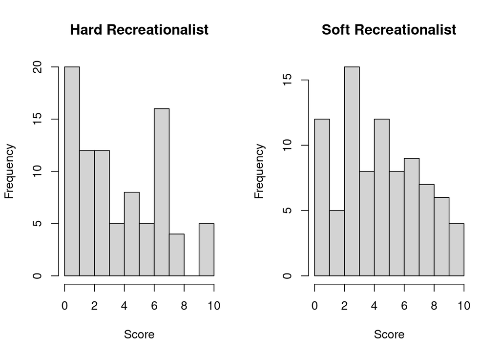

```r
par(mfrow = c(1, 2))

hist(hard_recreationalist,
    main = "Hard Recreationalist",
    breaks = 11,
    xlab = "Score",
    ylab = "Frequency")

hist(soft_recreationalist,
    main = "Soft Recreationalist",
    breaks = 11,
    xlab = "Score",
    ylab = "Frequency")
```

## Hard versus Soft Recreationalist

Let us compare the two personas in the ‘example’ region, which is just south of Edinburgh.

```r
bbox <- get_example_bbox()
```

To compute Recreational Potential, as well as each individual component, we use the `compute_potential` function. This returns a raster with 5 named layers.

```r
layers <- compute_potential(hard_recreationalist, bbox)
```

```
Selected an area of 3.1e+07 m^2 .
```

```r
names(layers)
```

```
[1] "SLSRA"                  "FIPS_N"                 "FIPS_I"
[4] "Water"                  "Recreational_Potential"
```

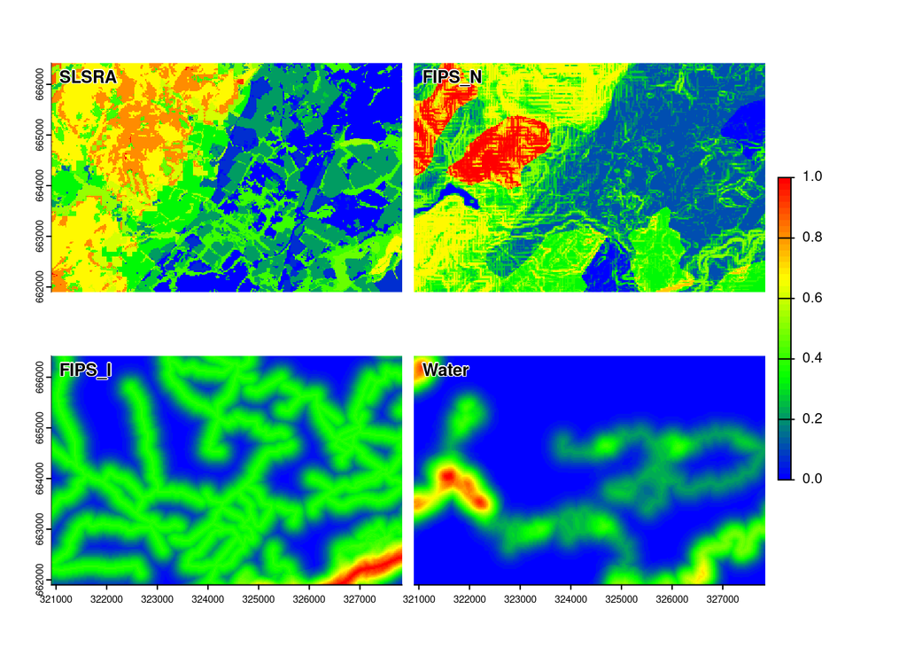

```r
palette <- terra::map.pal("bgyr")

terra::panel(terra::subset(layers, 1:4), nc=2, col=palette)
```

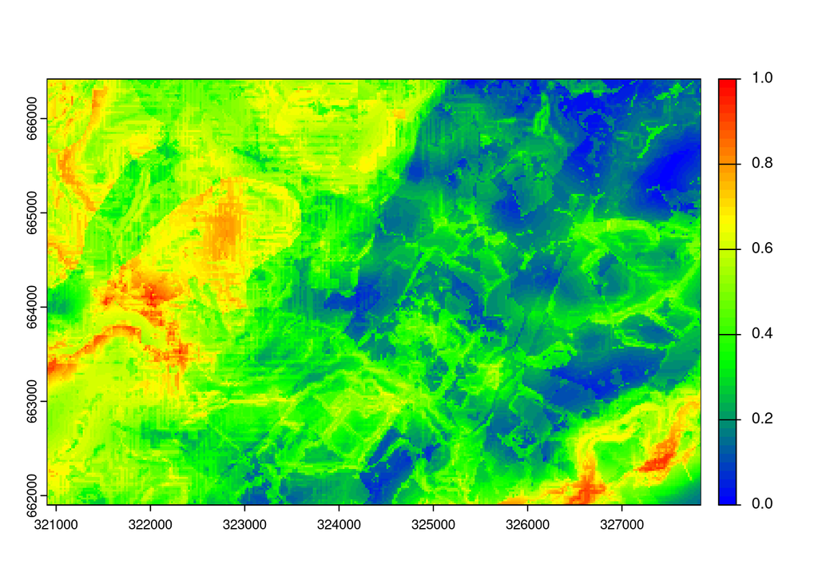

```r
terra::plot(layers[["Recreational_Potential"]], col=palette)
```

For comparison, here are the results using the *Soft Recreationalist* persona.

```r
layers <- compute_potential(soft_recreationalist, bbox)
```

```
Selected an area of 3.1e+07 m^2 .
```

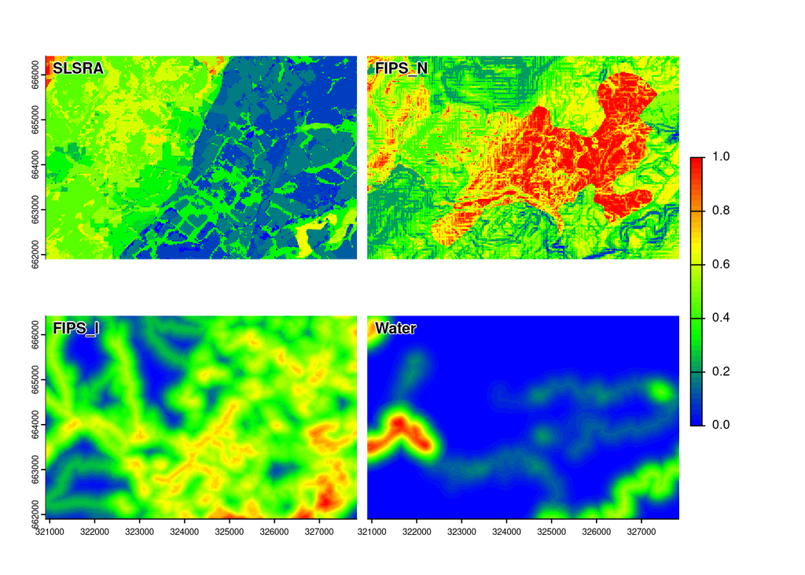

```r
terra::panel(terra::subset(layers, 1:4), nc=2, col=palette)
```

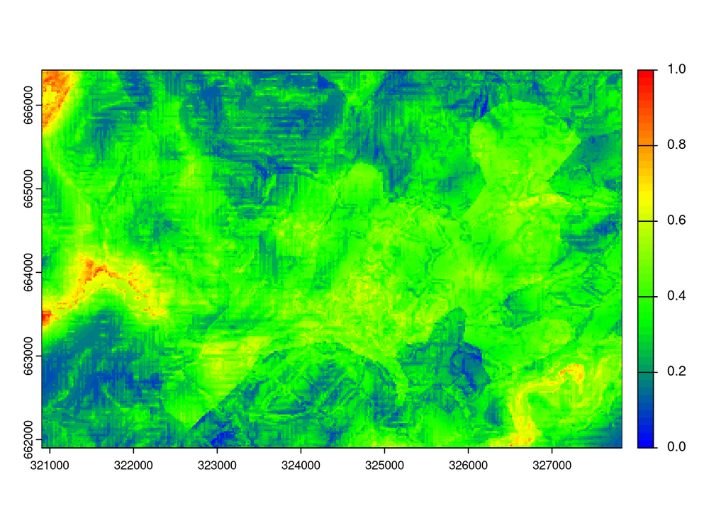

```r
terra::plot(layers[["Recreational_Potential"]], col=palette)
```

## More involved example (to do)

A region of interest may be given by a path to a shapefile, but the main supported format is a set of four coordinates defining a rectangular area, or ‘bounding box’. These can be easily constructed using [`terra::ext`](https://rspatial.github.io/terra/reference/ext.html) by passing a vector `(xmin, xmax, ymin, ymax)` as its first argument.

Creating or editing personas is far easier using the Shiny app, some spreadsheet software, or even just a text editor. However, for completeness, we demonstrate how to edit a persona dynamically within `R`.

## Access to code & data

Code for the Recreational Potential model is available as an R Package hosted on GitHub at https://github.com/BioDT/uc-ces-recreation. These reports relate specifically to the [version 1.0 release](https://github.com/BioDT/uc-ces-recreation/releases/tag/v1.0), which is also available on Zenodo at https://doi.org/10.5281/zenodo.15705544.

The model requires some input data that is too large to be bundled in with the package, but which can be downloaded from Dropbox after package installation using `biodt.recreation::download_data()`. This data is also included in the Zenodo listing.

The source for these documents and this website can be found at https://github.com/BioDT/ces-recreation-reports.

## Funding

Funding for OpenNESS came from the European Community’s Seventh Framework Programme (FP7/2007-2013) under grant agreement no 308428, OpenNESS Project (Operationalisation of Natural Capital and Ecosystem Services: From Concepts to Real-world Applications.)

Funding for BioDT came from the European Union’s Horizon Europe Research and Innovation Programme under grant agreement No 101057437 (BioDT project, https://doi.org/10.3030/101057437). Views and opinions expressed are those of the author(s) only and do not necessarily reflect those of the European Union or the European Commission. Neither the European Union nor the European Commission can be held responsible for them.

Funding for SPEAK came from the Natural Environment Research Council – Growing Shoots Partnership and application co-creation bursary. NE/Y005805/1 _Growing Shoots.

## CRediT statement

**JMR** and **MT** developed the current version of the model, and wrote the original drafts of these reports. **CA** obtained the input data and developed the previous version of the model. **CA** and **JD** conceptualised the SPEAK project and carried out the ananalysis. **CA**, **JD** and **SR** acquired funding for the project under BioDT.

## Acknowledgements

We wish to acknowledge significant contributions to a previous version of the Recreational Potential model by Will Bolton. JMR would also like to thank Tomáš Martinovič for assisting with understanding the requirements of BioDT.

We are very grateful to all the participants of the SPEAK project which this output is based on including: Alastair Leaver, Alice MacSporran, Brian Cassidy, Chris Pollock, David Giles, Jean Cowie, Joanna Gilliatt, Justyna Olszewska, Laura Taylor, Maddi Bunker, Rebecca MacLennan, S Mayes, Shaila Rao, Steve MacKinnon and Tom Gebbie, Active Stirling. We are equally grateful to an additional 18 participants who preferred to remain anonymous.

## Correspondence

- `{jand,chan}@ceh.ac.uk` for enquiries relating to the BioDT or SPEAK projects, or ongoing and future work.
- `chan@ceh.ac.uk` for enquiries relating to the data sources and QGIS processing.
- `{joemar,madtig}@ceh.ac.uk` for enquiries relating to the code and anything else appearing in the technical supplement and/or developer’s report.
- `simrol@ceh.ac.uk` for enquiries relating to the biodiversity component of the BioDT project.

## Footnotes

[^1]: Since future updates to the code may be incompatible with this notebook, we will target the specific version released at the time this notebook was written, i.e. version 1.0

## Copyright

BioDT and the UK Centre for Ecology & Hydrology, 2025